# StatBI/E Week 1

[This is how exercises are highlighted]

[This is how your answers are highlighted]

## Exercise 1 A case study of DNA sequence

Let $\Omega$ be the sample space of a single DNA nucleotide type,
$$\Omega =
\{ A, T, C, G \}.$$

Suppose that all four nucleotide types have equal probabilities in the genome and all locations in the DNA are independent.

A DNA motif is a specific sequence of nucleotides, for example AATG or CGGCC. The number of nucleotides in the motif is called the length of the motif.

### Exercise 1.1

Describe the sample space of DNA sequences of length 2.

$$\Theta = \Omega \times \Omega = \Omega
^2 = \{ (A,A), (A,T), \ldots, (A,G), (T,A), (T,T) \ldots (G,G) \}$$

### Exercise 1.2

Consider a DNA sequence of length 5. Describe the event of observing the motif ACG inside the DNA sequence.

$$E = \{ ACG**,\, *ACG*,\, **ACG \}$$
where $*$ indicates any nucleotide in $\Omega$.

What is the probability of this event?

Observe that the events $ACG**,\, *ACG*,\, **ACG$ are disjoint. Thus

$$P(E) = P(ACG**)+ P(*ACG*) + P(**ACG)$$

Moreover
$$P(ACG**) = P(*ACG*) = P(**ACG)
= \left(\frac{1}{4}\right)^3$$
since the events in different positions are independent. Thus

$$P(E) = 3 \left( \frac{1}{4}
\right)^3$$

```r
3 * (0.25)^3
```

```
## [1] 0.046875
```

### Exercise 1.3

Suppose we observe one nucleotide in the genome at a time. We keep observing until we find the nucleotide G. Describe the sample space of the observed DNA sequence. What is the probability that the DNA sequence observed before observing G has length 10?

$$S = \{ G, *G, **G, ***G, \ldots
\}$$

$$P(\text{length sequence before
observing G }= 10)
= (1-0.25)^{10} (0.25)$$

```r
(1-0.25)^(10) * (0.25)
```

```
## [1] 0.01407838
```

### Exercise 1.4

Now we drop the independence assumption. Suppose that the probability of observing A,T,C or G given the previous nucleotide being C, is respectively 0.2, 0.2, 0.5, 0.1. In general in different locations of the DNA sequence, this conditional probabilities will be different and this fact is important for sequence detection.

1. Suppose we observe C at a given location, what is the probability of observing the motif CG immediately after?

$$P( \text{observing CG starting from
position 2}|
\text{observe C in position 1}) = ?$$

Lets introduce three *extended* random variable $D_1$, $D_2$, $D_3$, indicating the nucleotide in position 1,2 and 3.
$$D_1, D_2, D_3$$

We want to compute,
$$\begin{align}
&P(D_2 = C, D_3 = G | D_1 = C)\\
= &
P(D_3 = G | D_2 = C , D_1 = C) P(D_2 = C | D_1 = C)\\
= &
0.1 \times 0.5 = 0.05
\end{align}$$

2. Suppose now in a different region of the DNA sequence, the conditional probabilities of A, T, C, G given C are 0.1, 0.2, 0.3, 0.4. In that DNA sequence region, what is the probability of observing CG given that we observed C in the previous location?

Similarly to above

$$\begin{align}
&P(D_2 = C, D_3 = G | D_1 = C)\\
= &
P(D_3 = G | D_2 = C , D_1 = C) P(D_2 = C | D_1 = C)\\
= &
0.4 \times 0.3 = 0.12
\end{align}$$

## Exercise 2 Some simulations in R

We now conduct some simulations in R for the DNA case study.

### Exercise 2.1

Run a simulation of Exercise 1.2 and check the probability of observing the motif ACG in a sequence of length 5. Idea: generate a sequence of length 5 and check if it contains the motif ACG. Repeat the above sampling and checking procedure 1000, 10000, or 100000 times. For each case obtain the proportion of sequences containing the motif ACG. Use these proportions as an approximation of the probability of observing the motif ACG.

```r
simulate_sequence <- function(length = 1,
                              nucleotides = c("A", "T", "C", "G")) {
  sample(nucleotides, size = length, replace = TRUE)
}

check_motif_present <- function(sequence, motif = c("A", "C", "G")) {
  length(grep(
    pattern = paste0(motif, collapse = ""),
    x = paste0(sequence, collapse = "")
  )) > 0
}

estimate_motif_prob <- function(length = 5,
                                motif = c("A", "C", "G"),
                                N = 1000) {
  dna_sequences <- t(replicate(N, simulate_sequence(length)))
  prob <-
    sum(apply(dna_sequences, MARGIN = 1, FUN = check_motif_present)) / N
  return(prob)
}
estimate_motif_prob(N = 1000)
```

```
## [1] 0.035
```

```r
estimate_motif_prob(N = 10000)
```

```
## [1] 0.0461
```

```r
estimate_motif_prob(N = 100000)
```

```
## [1] 0.04647
```

### Exercise 2.2

Run an R simulation of Exercise 1.3 and calculate the probability of observing 10 nucleotides before G, using 10000 repetitions.

```r
tryBefore <- function(before = "G", max = Inf) {
  x <- simulate_sequence(1)
  k <- 0
  while (x != before & k <= max) {
    x <- simulate_sequence(1)
    k <- k + 1
  }
  return(k)
}

N <- 100000
sum(replicate(N, tryBefore("G", 11)) == 10) / N
```

```
## [1] 0.01407
```

### Exercise 2.3

Repeat Exercise 2.2 for different lengths of the sequence $\{0,1,2,\ldots, 20\}$. Show the result in a scatter plot, with the sequence lengths $\{0,1,\ldots, 20\}$ on the x-axis and the approximated probabilities on the y-axis. Now also add the true probabilities (as derived in Exercise 1.3) to the plot.

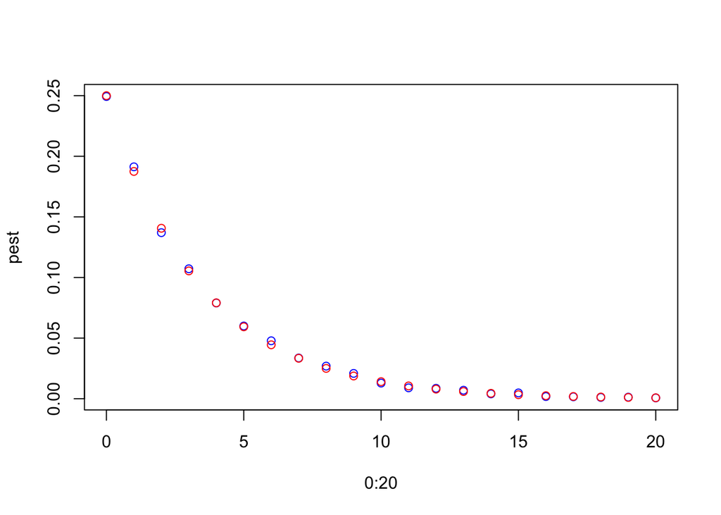

```r
N <- 10000

# estimation as before
pest <- sapply(0:20, function(i) {
  sum(replicate(N, tryBefore("G", i + 1)) == i) / N
})

# real prob
preal <- sapply(1:21, function(i) {
  return(0.75 ^ (i - 1) * 0.25)
})

plot(0:20, pest, col = "blue")
points(0:20, preal, col = "red")
```